# Inferência: foco em diferenças entre avaliações de filmes

Hadrizia Santos

21 de julho de 2018

Este relatório tem o objetivo de fazer inferências com foco na diferença entre populações. Neste caso, os dados são sobre os dados de filmes disponíveis no MovieLens.

## Importando bibliotecas

```r
knitr::opts_chunk$set(echo = TRUE)
library(here)
library(readr)
library(tidyverse)
library(resample)
library(timeDate)
library(lubridate)
library(stringr)
theme_set(theme_bw())
```

## Importando e conhecendo os dados

```r
ratings <- read.csv(here::here("/data/ratings.csv")) %>% na.omit()
movies <- read.csv(here::here("/data/movies.csv")) %>% na.omit()
data <- merge(ratings, movies,  by='movieId')
data <- data %>%
  mutate(date =
            as.Date(as.POSIXct(timestamp, origin="1970-01-01")),
         is_weekend = isWeekend(date)
         ) %>%
  select(-timestamp)
colnames(data)
```

```
[1] "movieId"    "userId"     "rating"     "title"      "genres"
[6] "date"       "is_weekend"
```

Os dados estão distribuídos nas seguintes colunas:

- `userId`: Identificador do usuário;
- `movieId`: Identificador do filme;
- `rating`: A avaliação dada por um usuário a um filme.
- `title`: O título do filme;
- `genres`: Os gêneros do filme;
- `date`: As datas;
- `is_weekend`: Se a data é um fim de semana (Sábado ou Domingo).

## Perguntas

### 1. Há diferenças significativas entre as avaliações gêneros Sci-Fi e Horror durante a semana e o fim de semana?

#### Sci-Fi

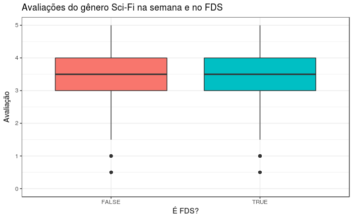

```r
scifi_data <- data %>% filter(str_detect(genres, regex('Sci-Fi', ignore_case = TRUE)))
scifi_data %>% group_by(is_weekend) %>%
  ggplot(aes(x = is_weekend,
             y = rating,
             fill=is_weekend)) +
  geom_boxplot() +
  ggtitle("Avaliações do gênero Sci-Fi na semana e no FDS") +
  labs(x = "É FDS?", y = 'Avaliação') +
  ylim(0,5) +
  theme(legend.position="none")
```

**Inferência com duas amostras:**

```r
median.week_day = scifi_data %>%
  filter(!is_weekend) %>%
  bootstrap(mean(rating),
            R = 2000) %>%
    CI.percentile(probs = c(.025, .975))
median.week_day
```

```
                 2.5%    97.5%
mean(rating) 3.447305 3.490073
```

```r
median.weekend = scifi_data %>%
  filter(is_weekend) %>%
  bootstrap(mean(rating),
            R = 2000) %>%
    CI.percentile(probs = c(.025, .975))
median.weekend
```

```
                 2.5%    97.5%
mean(rating) 3.409053 3.471422
```

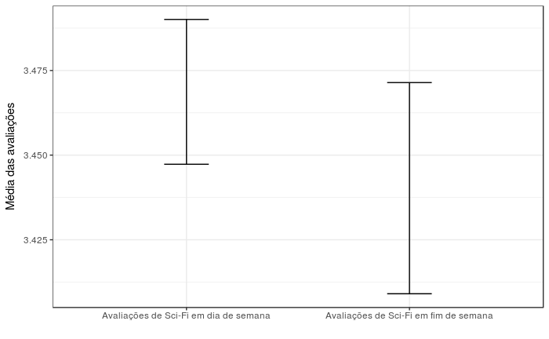

```r
df = data.frame(rbind(median.week_day,
                      median.weekend))
df$medida = c('Avaliações de Sci-Fi em dia de semana', 'Avaliações de Sci-Fi em fim de semana')
df %>%
  ggplot(aes(x = medida, ymin = X2.5., ymax = X97.5.)) +
  geom_errorbar(width = .2) +
  labs(x = "", y = 'Média das avaliações')
```

##### Horror

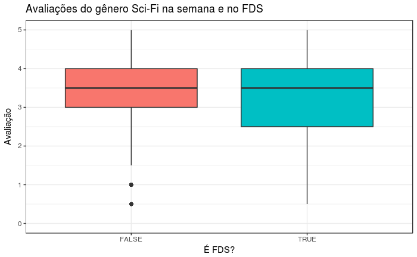

```r
horror_data <- data %>% filter(str_detect(genres, regex('Horror', ignore_case = TRUE)))
horror_data %>% group_by(is_weekend) %>%
  ggplot(aes(x = is_weekend,
             y = rating,
             fill=is_weekend)) +
  geom_boxplot() +
  ggtitle("Avaliações do gênero Sci-Fi na semana e no FDS") +
  labs(x = "É FDS?", y = 'Avaliação') +
  ylim(0,5) +
  theme(legend.position="none")
```

```r
median.week_day = horror_data %>%
  filter(!is_weekend) %>%
  bootstrap(mean(rating),
            R = 2000) %>%
    CI.percentile(probs = c(.025, .975))
median.week_day
```

```
                 2.5%    97.5%
mean(rating) 3.298421 3.358461
```

```r
median.weekend = horror_data %>%
  filter(is_weekend) %>%
  bootstrap(mean(rating),
            R = 2000) %>%
    CI.percentile(probs = c(.025, .975))
median.weekend
```

```
                 2.5%    97.5%
mean(rating) 3.219046 3.322102
```

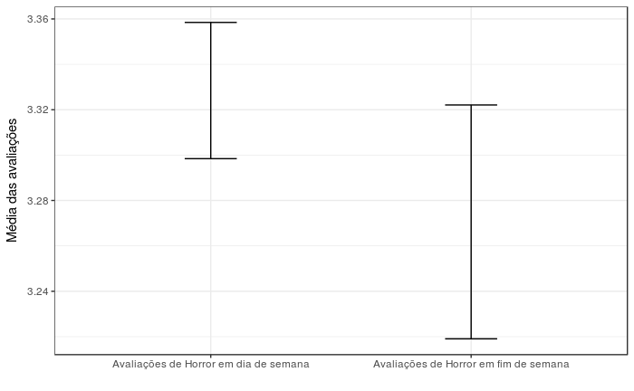

```r
df = data.frame(rbind(median.week_day,
                      median.weekend))
df$medida = c('Avaliações de Horror em dia de semana', 'Avaliações de Horror em fim de semana')
df %>%
  ggplot(aes(x = medida, ymin = X2.5., ymax = X97.5.)) +
  geom_errorbar(width = .2) +
  labs(x = "", y = 'Média das avaliações')
```

### 2. E no fim de semana, as diferenças de avaliações entre os gêneros Sci-Fi e Horror é grande?

**Diferenças não pareadas**

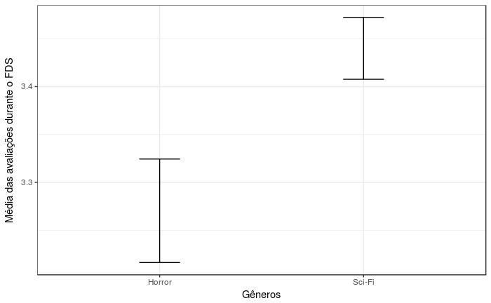

No geral, o gráficos acima mostra que, nos finais de semana, os usuários avaliam melhor os filmes do gênero SciFi do que os do gênero Horror.

### 3.Há diferenças significativas entre as avaliações dos filmes Meninas Malvadas e As branquelas durante a semana e no fim de semana?

#### Meninas Malvadas

```r
meangirls_data <- data %>% filter(str_detect(title, regex('^Mean Girls', ignore_case = TRUE)))

meangirls_data %>% group_by(is_weekend) %>%
  ggplot(aes(x = is_weekend,
             y = rating,
             fill=is_weekend)) +
  geom_boxplot() +
  ggtitle("Avaliações do filme Meninas Malvadas na semana e no FDS") +
  labs(x = "É FDS?", y = 'Avaliação') +
  ylim(0,5) +
  theme(legend.position="none")
```

[output not shown]

[figure not shown]

Pelo gráfico acima nota-se que, as avaliações durante a semana chegam a ter notas maiores mas também menores, com um intervalo grande entre as notas, de 2.5 a 4.5. Já no fim de semana, esse valor varia entre 3 e 4.

#### As branquelas

[figure not shown]

```r
median.week_day = chicks_data %>%
  filter(!is_weekend) %>%
  bootstrap(median(rating),
            R = 2000) %>%
    CI.percentile(probs = c(.025, .975))
median.week_day
```

```
               2.5% 97.5%
median(rating)  1.5   3.5
```

```r
median.weekend = chicks_data %>%
  filter(is_weekend) %>%
  bootstrap(median(rating),
            R = 2000) %>%
    CI.percentile(probs = c(.025, .975))
median.weekend
```

```
               2.5% 97.5%
median(rating)    2   3.5
```

```r
df = data.frame(rbind(median.week_day,
                      median.weekend))
```

```
some row.names duplicated: 2 --> row.names NOT used
```

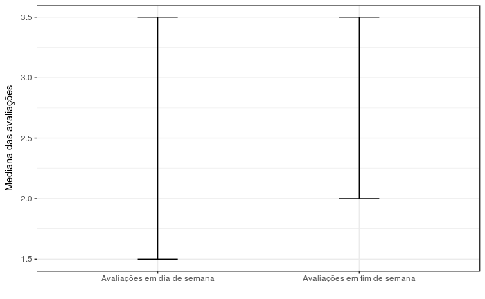

```r
df$medida = c('Avaliações em dia de semana', 'Avaliações em fim de semana')
df %>%
  ggplot(aes(x = medida, ymin = X2.5., ymax = X97.5.)) +
  geom_errorbar(width = .2) +
  labs(x = "", y = 'Mediana das avaliações')
```

Pode-se perceber do gráfico acima que nos finais de semanas, as menores notas dadas ao filme As branquelas são ainda maiores que as menores notas dadas duranre a semana.

### 4. Durante o fds, os filmes possuem acima citados possuem diferença de avaliação significativa?

```r
b1 = meangirls_data %>%
  filter(is_weekend) %>%
  bootstrap(mean(rating))
mean_girls = b1 %>%
  CI.percentile(probs = c(.025, .975))
b2 = chicks_data %>%
  filter(is_weekend) %>%
  bootstrap(mean(rating))
mean_chicks = b2 %>%
  CI.percentile(probs = c(.025, .975))
df.median = data.frame(rbind(mean_girls,
                             mean_chicks))
```

```
some row.names duplicated: 2 --> row.names NOT used
```

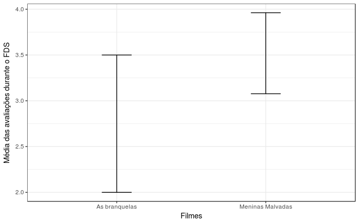

```r
df.median$medida = c("Meninas Malvadas", "As branquelas")
df.median %>%
  ggplot(aes(x = medida, ymin = X2.5., ymax = X97.5.)) +
  geom_errorbar(width = .2) + labs(x = "Filmes", y = "Média das avaliações durante o FDS")
```